# MAP 541 Homework 02

Sebastien Moeller

14/03/2018

# Objectives

The purpose of this homework is to build an image recognition system, using transfer learning and fine-tuning based on pre tuned convolutional neural networks on ImageNet. (http://www.image-net.org/). I started with keras pre trained model (see for instance https://keras.rstudio.com/articles/applications.html).

# Exercise 1 – Image Net

#### What is Image Net?

ImageNet is an image database organised according to the WordNet hierarchy (currently only the nouns), in which each node of the hierarchy is depicted by hundreds and thousands of images. Currently there is an average of over five hundred images per node.

#### ImageNet Cheese

How many different kinds of cheese can we find in ImageNet? The query ‘cheese’ matches 30 synsets.

#### Best classifier

What is the best classifier on ImageNet and what is its error rate?

The winner of the 2017 challenge used the following:

Adaptive attention[1] and deep combined convolutional models[2,3] are used for LOC task. Scale[4,5,6], context[7], sampling and deep combined convolutional networks[2,3] are considered for DET task. Object density estimation is used for score re-rank. With a mean AP of 0.731613.

# Exercise 2 – Build an image recognition system

Build an image recognition system for a 1000 everyday object categories (ImageNet ILSVRC) using Keras and TensorFlow.

#### Install keras

```r
if (!require('pacman')) install.packages('pacman')
```

```r
pacman::p_load(tensorflow, reticulate, keras, ggplot2, ggthemes, EBImage)
theme_set(theme_solarized_2(light = FALSE))

# Keras needs to be install after loading the package
# if(!is_keras_abailable()){
#   install_keras()
# }
```

#### ResNet50

Define ResNet50 as we model and check its architecture

```r
model0 <- application_resnet50(weights <- 'imagenet')
summary(model0)
```

```
## ___________________________________________________________________________
## Layer (type)            Output Shape     Param #  Connected to
## ===========================================================================
## input_1 (InputLayer)    (None, 224, 224, 0
## ___________________________________________________________________________
## conv1_pad (ZeroPadding2 (None, 230, 230, 0        input_1[0][0]
## ___________________________________________________________________________
## conv1 (Conv2D)          (None, 112, 112, 9472     conv1_pad[0][0]
## ___________________________________________________________________________
## bn_conv1 (BatchNormaliz (None, 112, 112, 256      conv1[0][0]
## ___________________________________________________________________________
## activation_1 (Activatio (None, 112, 112, 0        bn_conv1[0][0]
## ___________________________________________________________________________
## max_pooling2d_1 (MaxPoo (None, 55, 55, 6 0        activation_1[0][0]
## ___________________________________________________________________________
## res2a_branch2a (Conv2D) (None, 55, 55, 6 4160     max_pooling2d_1[0][0]
## ___________________________________________________________________________
## bn2a_branch2a (BatchNor (None, 55, 55, 6 256      res2a_branch2a[0][0]
## ___________________________________________________________________________
## activation_2 (Activatio (None, 55, 55, 6 0        bn2a_branch2a[0][0]
## ___________________________________________________________________________
## res2a_branch2b (Conv2D) (None, 55, 55, 6 36928    activation_2[0][0]
## ___________________________________________________________________________
## bn2a_branch2b (BatchNor (None, 55, 55, 6 256      res2a_branch2b[0][0]
## ___________________________________________________________________________
## activation_3 (Activatio (None, 55, 55, 6 0        bn2a_branch2b[0][0]
## ___________________________________________________________________________
## res2a_branch2c (Conv2D) (None, 55, 55, 2 16640    activation_3[0][0]
## ___________________________________________________________________________
## res2a_branch1 (Conv2D)  (None, 55, 55, 2 16640    max_pooling2d_1[0][0]
## ___________________________________________________________________________
## bn2a_branch2c (BatchNor (None, 55, 55, 2 1024     res2a_branch2c[0][0]
## ___________________________________________________________________________
## bn2a_branch1 (BatchNorm (None, 55, 55, 2 1024     res2a_branch1[0][0]
## ___________________________________________________________________________
## add_1 (Add)             (None, 55, 55, 2 0        bn2a_branch2c[0][0]
##                                                   bn2a_branch1[0][0]
## ___________________________________________________________________________
## activation_4 (Activatio (None, 55, 55, 2 0        add_1[0][0]
## ___________________________________________________________________________
```

[output cut: 322 more lines]

```
## add_16 (Add)            (None, 7, 7, 204 0        bn5c_branch2c[0][0]
##                                                   activation_46[0][0]
## ___________________________________________________________________________
## activation_49 (Activati (None, 7, 7, 204 0        add_16[0][0]
## ___________________________________________________________________________
## avg_pool (AveragePoolin (None, 1, 1, 204 0        activation_49[0][0]
## ___________________________________________________________________________
## flatten_1 (Flatten)     (None, 2048)     0        avg_pool[0][0]
## ___________________________________________________________________________
## fc1000 (Dense)          (None, 1000)     2049000  flatten_1[0][0]
## ===========================================================================
## Total params: 25,636,712
## Trainable params: 25,583,592
## Non-trainable params: 53,120
## ___________________________________________________________________________
```

#### Other pre-trained networks

The available networks currently include: Xception, VGG16, VGG19, ResNet50, InceptionV3, InceptionResNetV2, MobileNet, DenseNet, NASNet

#### Opening an Image

open an image (‘my_image.jpg’ in the following example) representing a single object (if possible represented in ImageNet)

```r
img_path <- 'hot_air_balloon.jpeg'
img <- image_load(img_path, target_size = c(224,224))

# Reshape the image to fit the input format of wer model
x <- image_to_array(img)
x <- array_reshape(x, c(1, dim(x)))

# Preprocess the input
x <- imagenet_preprocess_input(x)

# get the model predictions
preds <- model0 %>% predict(x)
```

#### display the top 5 recognised objects. Do we find the one represented on our image?

```r
imagenet_decode_predictions(preds, top <- 5)[[1]]
```

```
##   class_name class_description      score
## 1  n02782093           balloon 0.67158592
## 2  n09332890          lakeside 0.11591361
## 3  n03888257         parachute 0.03832017
## 4  n03028079            church 0.03051641
## 5  n02692877           airship 0.02636838
```

The NN recognised the hot air balloons as balloons, it recognised the lakeside and interpreted the light house as a church. Overall a good classification.

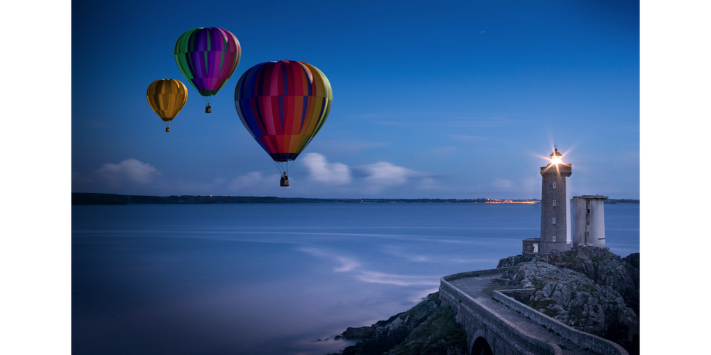

```r
img = readImage('hot_air_balloon.jpeg')
display(img, method = 'raster')
```

# Exercise 3 – Your Turn

### Binary Object Recognition

based on your previous work, build an binary object recognition (only two objects) by transfer learning and fine tuning.

Choose Two Classes: I chose cats and dogs.

Download images: Proceed adapting the code from https://keras.rstudio.com/articles/applications.html

I downloaded 50 images for each class and setup my data as follows:

```r
original_dataset_dir <- 'data/original'
base_dir <- 'data/cats_and_dogs'
dir.create(base_dir)

train_dir <- file.path(base_dir, 'train')
dir.create(train_dir)
validation_dir <- file.path(base_dir, 'validation')
dir.create(validation_dir)
test_dir <- file.path(base_dir, 'test')
dir.create(test_dir)

train_cats_dir <- file.path(train_dir, 'cats')
dir.create(train_cats_dir)

train_dogs_dir <- file.path(train_dir, 'dogs')
dir.create(train_dogs_dir)

validation_cats_dir <- file.path(validation_dir, 'cats')
dir.create(validation_cats_dir)

validation_dogs_dir <- file.path(validation_dir, 'dogs')
dir.create(validation_dogs_dir)

test_cats_dir <- file.path(test_dir, 'cats')
dir.create(test_cats_dir)

test_dogs_dir <- file.path(test_dir, 'dogs')
dir.create(test_dogs_dir)

fnames <- paste0('cat.', 1:30, '.jpg')
file.copy(file.path(original_dataset_dir, fnames),
          file.path(train_cats_dir))
```

```
##  [1] FALSE FALSE FALSE FALSE FALSE FALSE FALSE FALSE FALSE FALSE FALSE
## [12] FALSE FALSE FALSE FALSE FALSE FALSE FALSE FALSE FALSE FALSE FALSE
## [23] FALSE FALSE FALSE FALSE FALSE FALSE FALSE FALSE
```

```r
fnames <- paste0('cat.', 31:40, '.jpg')
file.copy(file.path(original_dataset_dir, fnames),
          file.path(validation_cats_dir))
```

```
##  [1] FALSE FALSE FALSE FALSE FALSE FALSE FALSE FALSE FALSE FALSE
```

```r
fnames <- paste0('cat.', 41:50, '.jpg')
file.copy(file.path(original_dataset_dir, fnames),
          file.path(test_cats_dir))
```

```
##  [1] FALSE FALSE FALSE FALSE FALSE FALSE FALSE FALSE FALSE FALSE
```

```r
fnames <- paste0('dog.', 1:30, '.jpg')
file.copy(file.path(original_dataset_dir, fnames),
          file.path(train_dogs_dir))
```

```
##  [1] FALSE FALSE FALSE FALSE FALSE FALSE FALSE FALSE FALSE FALSE FALSE
## [12] FALSE FALSE FALSE FALSE FALSE FALSE FALSE FALSE FALSE FALSE FALSE
## [23] FALSE FALSE FALSE FALSE FALSE FALSE FALSE FALSE
```

```r
fnames <- paste0('dog.', 31:40, '.jpg')
file.copy(file.path(original_dataset_dir, fnames),
          file.path(validation_dogs_dir))
```

```
##  [1] FALSE FALSE FALSE FALSE FALSE FALSE FALSE FALSE FALSE FALSE
```

```r
fnames <- paste0('dog.', 41:50, '.jpg')
file.copy(file.path(original_dataset_dir, fnames),
          file.path(test_dogs_dir))
```

```
##  [1] FALSE FALSE FALSE FALSE FALSE FALSE FALSE FALSE FALSE FALSE
```

Let’s instantiate the VGG16 model.

```r
conv_base <- application_vgg16(
  weights = 'imagenet',
  include_top = FALSE,
  input_shape = c(150, 150, 3)
)
```

We pass three arguments to the function:

– weights specifies the weight checkpoint from which to initialise the model.

– include_top refers to including (or not) the densely connected classifier on top of the network. By default, this densely connected classifier corresponds to the 1,000 classes from ImageNet. Because we intend to use our own densely connected classifier (with only two classes: cats and dogs), we don’t need to include it.

– input_shape is the shape of the image tensors that we’ll feed to the network. This argument is purely optional: if we don’t pass it, the network will be able to process inputs of any size.

Here’s the detail of the architecture of the VGG16 convolutional base. It’s similar to the simple convnets.

```r
summary(conv_base)
```

```
## ___________________________________________________________________________
## Layer (type)                     Output Shape                  Param #
## ===========================================================================
## input_2 (InputLayer)             (None, 150, 150, 3)           0
## ___________________________________________________________________________
## block1_conv1 (Conv2D)            (None, 150, 150, 64)          1792
## ___________________________________________________________________________
## block1_conv2 (Conv2D)            (None, 150, 150, 64)          36928
## ___________________________________________________________________________
## block1_pool (MaxPooling2D)       (None, 75, 75, 64)            0
## ___________________________________________________________________________
## block2_conv1 (Conv2D)            (None, 75, 75, 128)           73856
## ___________________________________________________________________________
## block2_conv2 (Conv2D)            (None, 75, 75, 128)           147584
## ___________________________________________________________________________
## block2_pool (MaxPooling2D)       (None, 37, 37, 128)           0
## ___________________________________________________________________________
## block3_conv1 (Conv2D)            (None, 37, 37, 256)           295168
## ___________________________________________________________________________
## block3_conv2 (Conv2D)            (None, 37, 37, 256)           590080
## ___________________________________________________________________________
## block3_conv3 (Conv2D)            (None, 37, 37, 256)           590080
## ___________________________________________________________________________
## block3_pool (MaxPooling2D)       (None, 18, 18, 256)           0
## ___________________________________________________________________________
## block4_conv1 (Conv2D)            (None, 18, 18, 512)           1180160
## ___________________________________________________________________________
## block4_conv2 (Conv2D)            (None, 18, 18, 512)           2359808
## ___________________________________________________________________________
## block4_conv3 (Conv2D)            (None, 18, 18, 512)           2359808
## ___________________________________________________________________________
## block4_pool (MaxPooling2D)       (None, 9, 9, 512)             0
## ___________________________________________________________________________
## block5_conv1 (Conv2D)            (None, 9, 9, 512)             2359808
## ___________________________________________________________________________
## block5_conv2 (Conv2D)            (None, 9, 9, 512)             2359808
## ___________________________________________________________________________
## block5_conv3 (Conv2D)            (None, 9, 9, 512)             2359808
## ___________________________________________________________________________
## block5_pool (MaxPooling2D)       (None, 4, 4, 512)             0
## ===========================================================================
## Total params: 14,714,688
## Trainable params: 14,714,688
## Non-trainable params: 0
## ___________________________________________________________________________
```

At this point, there are two ways we could proceed:

– Running the convolutional base over our dataset, recording its output to an array on disk, and then using this data as input to a standalone, densely connected classifier. This solution is fast and cheap to run, because it only requires running the convolutional base once for every input image, and the convolutional base is by far the most expensive part of the pipeline. But for the same reason, this technique won’t allow us to use data augmentation.

– Extending the model we have (conv_base) by adding dense layers on top, and running the whole thing end to end on the input data. This will allow us to use data augmentation, because every input image goes through the convolutional base every time it’s seen by the model. But for the same reason, this technique is far more expensive than the first.

We will proceed with the second option. Note that this technique is very expensive and should only be attempted with a GPU for large sets.

Because models behave just like layers, we can add a model (like conv_base) to a sequential model just like we would add a layer.

```r
model <- keras_model_sequential() %>%
  conv_base %>%
  layer_flatten() %>%
  layer_dense(units = 256, activation = 'relu') %>%
  layer_dense(units = 1, activation = 'sigmoid')
```

This is what the model looks like now:

```r
summary(model)
```

```
## ___________________________________________________________________________
## Layer (type)                     Output Shape                  Param #
## ===========================================================================
## vgg16 (Model)                    (None, 4, 4, 512)             14714688
## ___________________________________________________________________________
## flatten_2 (Flatten)              (None, 8192)                  0
## ___________________________________________________________________________
## dense_1 (Dense)                  (None, 256)                   2097408
## ___________________________________________________________________________
## dense_2 (Dense)                  (None, 1)                     257
## ===========================================================================
## Total params: 16,812,353
## Trainable params: 16,812,353
## Non-trainable params: 0
## ___________________________________________________________________________
```

As we can see, the convolutional base of VGG16 has 14,714,688 parameters, which is very large. The classifier we’re adding on top has 2 million parameters.

Before we compile and train the model, it’s very important to freeze the convolutional base. Freezing a layer or set of layers means preventing their weights from being updated during training. If we don’t do this, then the representations that were previously learned by the convolutional base will be modified during training. Because the dense layers on top are randomly initialised, very large weight updates would be propagated through the network, effectively destroying the representations previously learned.

In Keras, we freeze a network using the `freeze_weights()` function:

```r
length(model$trainable_weights)
```

```r
freeze_weights(conv_base)
length(model$trainable_weights)
```

With this setup, only the weights from the two dense layers that we added will be trained. That’s a total of four weight tensors: two per layer (the main weight matrix and the bias vector). Note that in order for these changes to take effect, we must first compile the model. If we ever modify weight trainability after compilation, we should then recompile the model, or these changes will be ignored.

#### Data Augmentation

Overfitting is caused by having too few samples to learn from, rendering us unable to train a model that can generalise to new data. Given infinite data, the model would be exposed to every possible aspect of the data distribution at hand: we would never overfit. Data augmentation takes the approach of generating more training data from existing training samples, by augmenting the samples via a number of random transformations that yield believable-looking images. The goal is that at training time, the model will never see the exact same picture twice. This helps expose the model to more aspects of the data and generalise better.

In Keras, this can be done by configuring a number of random transformations to be performed on the images read by an `image_data_generator()`

```r
train_datagen = image_data_generator(
  rescale = 1/255,
  rotation_range = 40,
  width_shift_range = 0.2,
  height_shift_range = 0.2,
  shear_range = 0.2,
  zoom_range = 0.2,
  horizontal_flip = TRUE,
  fill_mode = 'nearest'
)
```

Now we can train our model using the image data generator:

```r
set.seed(100)
# Note that the validation data shouldn't be augmented!
test_datagen <- image_data_generator(rescale = 1/255)

train_generator <- flow_images_from_directory(
  train_dir,                  # Target directory
  train_datagen,              # Data generator
  target_size = c(150, 150),  # Resizes all images to 150 × 150
  batch_size = 5,
  class_mode = 'binary'       # binary_crossentropy loss for binary labels
)

validation_generator <- flow_images_from_directory(
  validation_dir,
  test_datagen,
  target_size = c(150, 150),
  batch_size = 5,
  class_mode = 'binary'
)

model %>% compile(
  loss = 'binary_crossentropy',
  optimizer = optimizer_rmsprop(lr = 2e-5),
  metrics = c('accuracy')
)

history <- model %>% fit_generator(
  train_generator,
  steps_per_epoch = 6,
  epochs = 15,
  validation_data = validation_generator,
  validation_steps = 10
)
```

```r
epochTimeline <- as.data.frame(history$metrics)
epochTimeline$epoch <- seq(1,15)
```

```r
p1 <- ggplot(epochTimeline) +
  geom_point(aes(epoch, loss), size = 2, color = 'tan1') +
  geom_line(aes(epoch, loss), color = 'tan1') +
  geom_point(aes(epoch, val_loss), size = 2, color = 'seagreen3') +
  geom_line(aes(epoch, val_loss), color = 'seagreen3') +
  geom_hline(yintercept = epochTimeline$loss[15], color = 'tan1') +
  annotate('text', 0, epochTimeline$loss[15], vjust = -.4, hjust = 0, label = paste0(round(epochTimeline$loss[15], 4), ' Training Loss'), color = 'tan1') +
  geom_hline(yintercept = epochTimeline$val_loss[15], color = 'seagreen3') +
  annotate('text', 0, epochTimeline$val_loss[15], vjust = -.4, hjust = 0, label = paste0(round(epochTimeline$val_loss[15], 4), ' Validation Loss'), color = 'seagreen3') +
  ggtitle('Transfer loss vs val_loss') +
  labs(x = 'Epoch', y = 'Loss') +
  theme(axis.text = element_text(colour = 'white'))

p1
ggsave('Transfer loss vs val_loss.png', width = 14, height = 7)
```

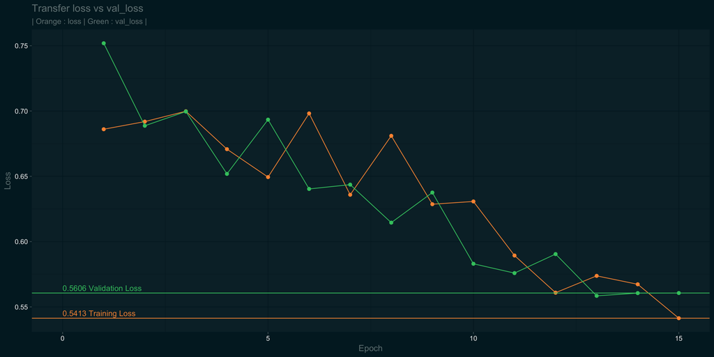

```r
img = readImage('Transfer loss vs val_loss.png')
display(img, method = 'raster')
```

```r
p2 <- ggplot(epochTimeline) +
  geom_line(aes(epoch, acc), color = 'tan1') +
  geom_point(aes(epoch, acc), size = 2, color = 'tan1') +
  geom_line(aes(epoch, val_acc), color = 'seagreen3') +
  geom_point(aes(epoch, val_acc), size = 2, color = 'seagreen3') +
  geom_hline(yintercept = epochTimeline$acc[15], color = 'tan1') +
  annotate('text', 0, epochTimeline$acc[15], vjust = -.4, hjust = 0, label = paste0(round(epochTimeline$acc[15], 4), ' Training Accuracy'), color = 'tan1') +
  geom_hline(yintercept = epochTimeline$val_acc[15], color = 'seagreen3') +
  annotate('text', 0, epochTimeline$val_acc[15], vjust = -.4, hjust = 0, label = paste0(round(epochTimeline$val_acc[15], 4), ' Validation Accuracy'), color = 'seagreen3') +
  ggtitle('Transfer acc vs val_acc') +
  labs(x = 'Epoch', y = 'Accuracy') +
  theme(axis.text = element_text(colour = 'white'))

p2
ggsave('Transfer acc vs val_acc.png', width = 14, height = 7)
```

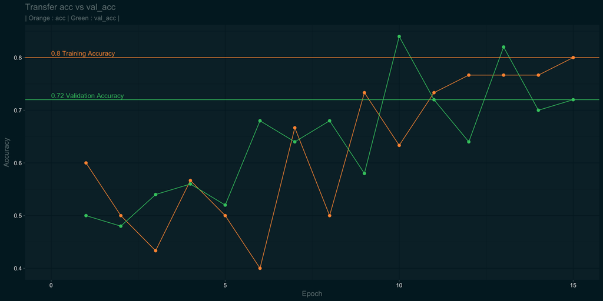

```r
img = readImage('Transfer acc vs val_acc.png')
display(img, method = 'raster')
```

Plotting the results of training the model, we reach a validation accuracy of `72%` and a training accuracy of `80%`.

#### Fine-Tuning

Another widely used technique for model reuse, complementary to feature extraction, is fine-tuning. Fine-tuning consists of unfreezing a few of the top layers of a frozen model base used for feature extraction, and jointly training both the newly added part of the model (in this case, the fully connected classifier) and these top layers. This is called fine-tuning because it slightly adjusts the more abstract representations of the model being reused, in order to make them more relevant for the problem at hand.

As stated earlier, it’s necessary to freeze the convolution base of VGG16 in order to be able to train a randomly initialised classifier on top. For the same reason, it’s only possible to fine-tune the top layers of the convolutional base once the classifier on top has already been trained. If the classifier isn’t already trained, then the error signal propagating through the network during training will be too large, and the representations previously learned by the layers being fine-tuned will be destroyed. Thus the steps for fine-tuning a network are as follows:

– Add our custom network on top of an already-trained base network.

– Freeze the base network.

– Train the part we added.

– Unfreeze some layers in the base network.

– Jointly train both these layers and the part we added.

We have already completed the first three steps when doing feature extraction. Let’s proceed with step 4: Unfreeze conv_base and then freeze individual layers inside it.

As a reminder, this is what the convolutional base looks like:

```r
summary(conv_base)
```

```
## ___________________________________________________________________________
## Layer (type)                     Output Shape                  Param #
## ===========================================================================
## input_2 (InputLayer)             (None, 150, 150, 3)           0
## ___________________________________________________________________________
## block1_conv1 (Conv2D)            (None, 150, 150, 64)          1792
## ___________________________________________________________________________
## block1_conv2 (Conv2D)            (None, 150, 150, 64)          36928
## ___________________________________________________________________________
## block1_pool (MaxPooling2D)       (None, 75, 75, 64)            0
## ___________________________________________________________________________
## block2_conv1 (Conv2D)            (None, 75, 75, 128)           73856
## ___________________________________________________________________________
## block2_conv2 (Conv2D)            (None, 75, 75, 128)           147584
## ___________________________________________________________________________
## block2_pool (MaxPooling2D)       (None, 37, 37, 128)           0
## ___________________________________________________________________________
## block3_conv1 (Conv2D)            (None, 37, 37, 256)           295168
## ___________________________________________________________________________
## block3_conv2 (Conv2D)            (None, 37, 37, 256)           590080
## ___________________________________________________________________________
## block3_conv3 (Conv2D)            (None, 37, 37, 256)           590080
## ___________________________________________________________________________
## block3_pool (MaxPooling2D)       (None, 18, 18, 256)           0
## ___________________________________________________________________________
## block4_conv1 (Conv2D)            (None, 18, 18, 512)           1180160
## ___________________________________________________________________________
## block4_conv2 (Conv2D)            (None, 18, 18, 512)           2359808
## ___________________________________________________________________________
## block4_conv3 (Conv2D)            (None, 18, 18, 512)           2359808
## ___________________________________________________________________________
## block4_pool (MaxPooling2D)       (None, 9, 9, 512)             0
## ___________________________________________________________________________
## block5_conv1 (Conv2D)            (None, 9, 9, 512)             2359808
## ___________________________________________________________________________
## block5_conv2 (Conv2D)            (None, 9, 9, 512)             2359808
## ___________________________________________________________________________
## block5_conv3 (Conv2D)            (None, 9, 9, 512)             2359808
## ___________________________________________________________________________
## block5_pool (MaxPooling2D)       (None, 4, 4, 512)             0
## ===========================================================================
## Total params: 14,714,688
## Trainable params: 14,714,688
## Non-trainable params: 0
## ___________________________________________________________________________
```

We will fine-tune all of the layers from `block3_conv1` and on. Why not fine-tune the entire convolutional base? We could, but we need to consider the following:

– Earlier layers in the convolutional base encode more-generic, reusable features, whereas layers higher up encode more-specialised features. It’s more useful to fine-tune the more specialised features, because these are the ones that need to be repurposed on our new problem. There would be fast-decreasing returns in fine-tuning lower layers.

– The more parameters we’re training, the more we’re at risk of overfitting. The convolutional base has 15 million parameters, so it would be risky to attempt to train it on our small dataset.

Thus, in this situation, it’s a good strategy to fine-tune only some of the layers in the convolutional base. Let’s set this up.

```r
unfreeze_weights(conv_base, from = 'block3_conv1')
```

```r
length(model$trainable_weights)
```

[output not shown]

This version of the model has `22` trainable weights, a significant increase from the first model’s `4`.

```r
model %>% compile(
  loss = 'binary_crossentropy',
  # low learning rate
  optimizer = optimizer_rmsprop(lr = 1e-5),
  metrics = c('accuracy')
)

history <- model %>% fit_generator(
  train_generator,
  steps_per_epoch = 6,
  epochs = 15,
  validation_data = validation_generator,
  validation_steps = 10
)
```

```r
epochFinetune <- as.data.frame(history$metrics)
epochFinetune$epoch <- seq(1,15)
```

```r
p3 <- ggplot(epochFinetune) +
  geom_point(aes(epoch, loss), size = 2, color = 'tan1') +
  geom_line(aes(epoch, loss), color = 'tan1') +
  geom_point(aes(epoch, val_loss), size = 2, color = 'seagreen3') +
  geom_line(aes(epoch, val_loss), color = 'seagreen3') +
  geom_hline(yintercept = epochFinetune$loss[15], color = 'tan1') +
  annotate('text', 0, epochFinetune$loss[15], vjust = -.4, hjust = -2, label = paste0(round(epochFinetune$loss[15], 4), ' Training Loss'), color = 'tan1') +
  geom_hline(yintercept = epochFinetune$val_loss[15], color = 'seagreen3') +
  annotate('text', 0, epochFinetune$val_loss[15], vjust = -.4, hjust = -2, label = paste0(round(epochFinetune$val_loss[15], 4), ' Validation Loss'), color = 'seagreen3') +
  ggtitle('Fine Tune loss vs val_loss') +
  labs(x = 'Epoch', y = 'Loss') +
  theme(axis.text = element_text(colour = 'white'))

p3
ggsave('Fine Tune loss vs val_loss.png', width = 14, height = 7)
```

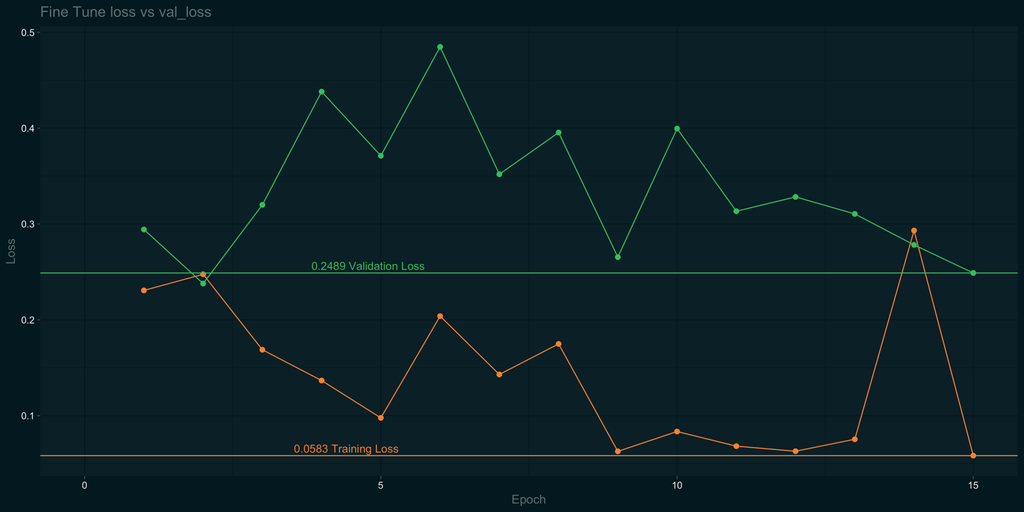

```r
img = readImage('Fine Tune loss vs val_loss.png')
display(img, method = 'raster')
```

```r
p4 <- ggplot(epochFinetune) +
  geom_line(aes(epoch, acc), color = 'tan1') +
  geom_point(aes(epoch, acc), size = 2, color = 'tan1') +
  geom_line(aes(epoch, val_acc), color = 'seagreen3') +
  geom_point(aes(epoch, val_acc), size = 2, color = 'seagreen3') +
  geom_hline(yintercept = epochFinetune$acc[15], color = 'tan1') +
  annotate('text', 0, epochFinetune$acc[15], vjust = -.4, hjust = 0, label = paste0(round(epochFinetune$acc[15], 4), ' Training Accuracy'), color = 'tan1') +
  geom_hline(yintercept = epochFinetune$val_acc[15], color = 'seagreen3') +
  annotate('text', 0, epochFinetune$val_acc[15], vjust = -.4, hjust = 0, label = paste0(round(epochFinetune$val_acc[15], 4), ' Validation Accuracy'), color = 'seagreen3') +
  ggtitle('Fine Tuning acc vs val_acc') +
  labs(x = 'Epoch', y = 'Accuracy') +
  theme(axis.text = element_text(colour = 'white'))

p4
ggsave('Fine Tune acc vs val_acc.png', width = 14, height = 7)
```

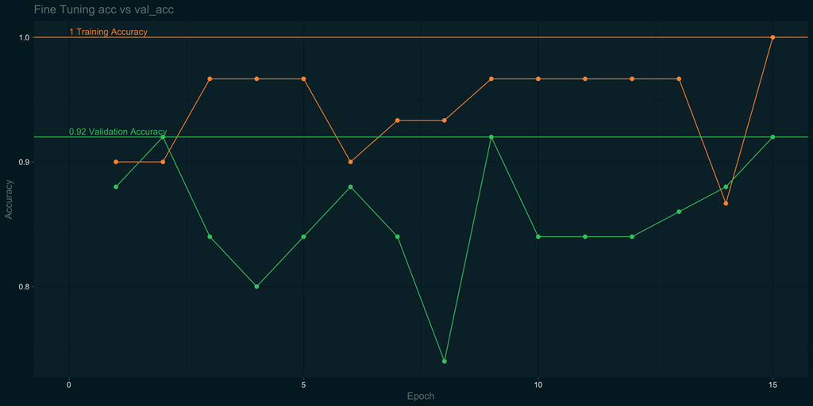

```r
img = readImage('Fine Tune acc vs val_acc.png')
display(img, method = 'raster')
```

### Transfer Learning vs Fine Tuning

Is it better to do transfer learning and fine tuning or both?

Transfer learning was imperative to building our neural network. By using the VGG16 architecture’s base, we were able to use previously trained layers as the base of our own classifier. We only needed to add our own layers on top to build a functioning classifier in a short amount of time.

Fine tuning on the other hand requires a base network to be unfrozen and modified at preferably a low learning rate. Limiting the learning rate effectively limits the magnitude of the modifications we make to the representations of the layers we’re fine-tuning. Updates that are too large may harm these representations. This is called fine-tuning because it slightly adjusts the more abstract representations of the model being reused, in order to make them more relevant for the problem at hand.

Only by using the two methods together do we achieve the best results.

The validation accuracy did increase from original model from `72%` from transfer learning to `92%` after fine-tuning. As we approach `100%` training accuracy we are overfitting the model, the most important metric is the validation accuracy. By the end of fine tuning we did in fact reach `100%` training accuracy.

```r
test_generator <- flow_images_from_directory(
  test_dir,
  test_datagen,
  target_size = c(150, 150),
  batch_size = 5,
  class_mode = "binary"
)
model %>% evaluate_generator(test_generator, steps = 5)
```

[output not shown]

This code checks the accuracy of the model on the testing set. The results of the classification is `80%` with an associated loss of `0.3261`. Based on the limited training data set, I believe that these metrics indicate that training the NN was successful.